# Group_10_Analysis

# Formative Data Analysis

We must model our data to include an indicator variable examining the difference between the number of people susceptible to measles before and after the article retraction.

It’s appropriate to model this data under a binomial assumption as long as we specify our successes/ failures appropriately:

We fit the GLM:

$$g(p_i) = logit(p_i) = \alpha + \beta_{year} \cdot year + \beta_{post2004} \cdot \mathbb{I}_{post2004} + \beta_{year,post2004} \cdot year \cdot \mathbb{I}_{post2004}$$

So that,

$$g(p_i) = logit(p_i) = \begin{cases}
\alpha + \beta_{year} \cdot year {\text{, for years before 2004}} \\
\alpha + \beta_{year} \cdot year + \beta_{post2004} + \beta_{year,post2004} \cdot year {\text{, otherwise}}
\end{cases}$$

This is where:

- $\alpha$ is our model intercept.
- $\beta_{year}$ is our model coefficient for ‘Year’ (in terms of an increase/decrease in log-odds).
- $\beta_{post2004}$ is our beta coefficient for the log-odds of susceptibility for years after 2004 compared to before.
- $\mathbb{I}_{post2004}$ is our indicator function where:

$$\mathbb{I}_{post2004} = \begin{cases}
1 ~ \text{if the observation is taken post-2004} \\
0 ~ \text{otherwise}
\end{cases}$$

- $\beta_{year,post2004}$ is our interaction term between our explanatory variables.

Here’s a visualisation of our model:

```
Call:
glm(formula = cbind(Y, successes) ~ Year + Post2004 + Year:Post2004,
    family = binomial, data = dataset)

Coefficients:
                Estimate Std. Error z value Pr(>|z|)
(Intercept)   -13.903016  25.532356  -0.545    0.586
Year            0.005798   0.012766   0.454    0.650
Post2004      181.475822  29.005216   6.257 3.93e-10 ***
Year:Post2004  -0.090572   0.014490  -6.251 4.08e-10 ***
---
Signif. codes:  0 '***' 0.001 '**' 0.01 '*' 0.05 '.' 0.1 ' ' 1

(Dispersion parameter for binomial family taken to be 1)

    Null deviance: 1596.0  on 706  degrees of freedom
Residual deviance: 1283.6  on 703  degrees of freedom
AIC: 3789.3

Number of Fisher Scoring iterations: 4
```

However, we must be careful to avoid modelling with overdispersion. The overdispersion ratio - $\hat{\phi} = \frac{\text{residual deviance}}{\text{df}_{\text{residual deviance}}}$ - gives us information on the overdispersion.

```
[1] 1.825831
```

This value is far greater than 1. This suggests that we have heavy overdispersion and we should adjust our model.

```
Call:
glm(formula = cbind(Y, successes) ~ Year * Post2004, family = quasibinomial,
    data = dataset)

Coefficients:
                Estimate Std. Error t value Pr(>|t|)
(Intercept)   -13.903016  35.466352  -0.392    0.695
Year            0.005798   0.017733   0.327    0.744
Post2004      181.475822  40.290414   4.504 7.80e-06 ***
Year:Post2004  -0.090572   0.020127  -4.500 7.95e-06 ***
---
Signif. codes:  0 '***' 0.001 '**' 0.01 '*' 0.05 '.' 0.1 ' ' 1

(Dispersion parameter for quasibinomial family taken to be 1.929529)

    Null deviance: 1596.0  on 706  degrees of freedom
Residual deviance: 1283.6  on 703  degrees of freedom
AIC: NA

Number of Fisher Scoring iterations: 4
```

Displayed above is our quasi-binomial model. The standard errors have changed to so that our intervals for significance are adjusted for overdispersion.

But, before we infer from our model, we have an extremely large coefficient for our ‘Post2004’ variable. It’s likely that - because of the scale of our ‘Year’ variable - this caused some interpretability issues.

Taking years before 2004 to be negative and years post 2004 to be positive:

```
Call:
glm(formula = cbind(Y, successes) ~ year_centered * Post2004,
    family = quasibinomial, data = dataset)

Coefficients:
                        Estimate Std. Error t value Pr(>|t|)
(Intercept)            -2.284255   0.077007 -29.663  < 2e-16 ***
year_centered           0.005798   0.017733   0.327    0.744
Post2004               -0.030784   0.090843  -0.339    0.735
year_centered:Post2004 -0.090572   0.020127  -4.500 7.95e-06 ***
---
Signif. codes:  0 '***' 0.001 '**' 0.01 '*' 0.05 '.' 0.1 ' ' 1

(Dispersion parameter for quasibinomial family taken to be 1.929529)

    Null deviance: 1596.0  on 706  degrees of freedom
Residual deviance: 1283.6  on 703  degrees of freedom
AIC: NA

Number of Fisher Scoring iterations: 4
```

Here our results are centered and easier to interpret.

To answer our first question: “Did Edinburgh exhibit a change in measles susceptibility following the retraction of the Wakefield article?” we examine our ‘year_centered:Post2004’ coefficient. Our coefficient is highly significant and negative, indicating a significant decrease in the log odds of susceptibility. Suggesting that there is actually a decrease in measles susceptibility after the retraction of the Wakefield article post 2004.

For our second question: “Did the change, if any, in measles susceptibility occur in 2004 alongside the articles’ retraction?” the answer appears to be no. Given our ‘Post2004’ variable isn’t significant. We can deduce that there existed no immediate jump in susceptibility in measles after the retraction. The change progressed - long term - afterwards.

Pseudo $R^2$ gives us a measure of model fit.

$$R^2 = 1 - \frac{\text{Residual deviance}}{\text{Null deviance}}$$

```
[1] 0.1957393
```

Therefore, our model explains 19.6% of variation in measles susceptibility. This is a weak to moderate fit. However, because of the complication within the modelling for our centered variable, indicator variable and our overdispersion this is a reasonable model to use.

Here are our diagnostic plots:

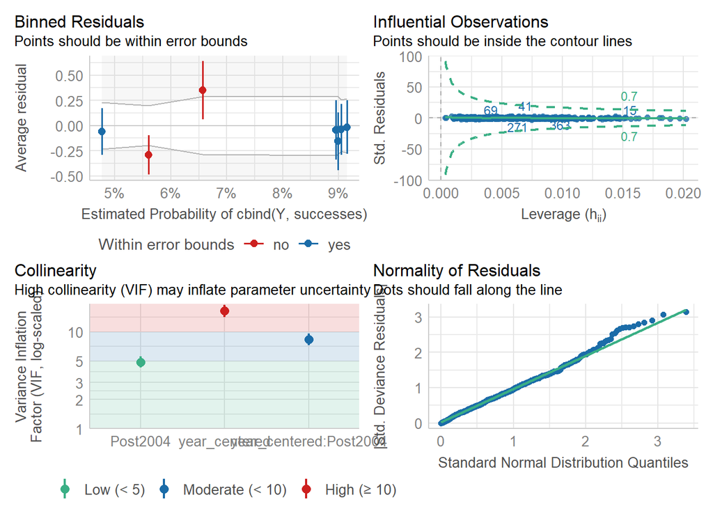